# How to succeed in this course

## Everyone can succeed in this class

> With **consistent** and **intentional** work, anyone can succeed in this class

Learning to be consistent and intentional is a skill that you will practice not only in this course, but in many aspects of your (academic) life

## What do you need to succeed in this class?

A willingness to:

- try and fail
- get frustrated and bored
- be curious about how things work

## How is the structure of this class designed to help you succeed?

- Active learning – you are expected to engage in the in-class activities (I want to hear from you, and what you are thinking)
- Deep processing – I will elicit knowledge from you and help you make connections to new content
- Small sequential steps – each week we build on top of the content of the previous week, make sure you are following along

## How is the structure of this class designed to help you succeed?

- Spaced repetition – this is not the type of course you can cram for 2 hours before the exam
- Mastery checks – frequent assessment

## LLMs (chatgpt etc.)

- Amazing tools
- I’ve seen students use them carelessly

## LLMs

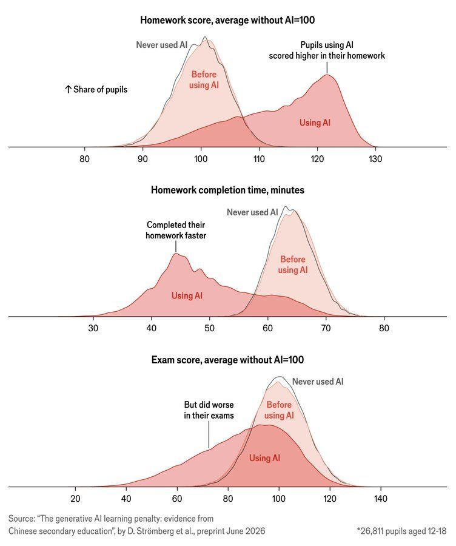

## LLMs

Rule 1: **Don’t** use LLM to:

- write code
- plan code and problem-solve
- debug code
- test code
- comment or format code

## LLMs

What’s allowed:

- Help you learn
- Help with non-graded practice tasks
- Help you connect to legitimate and useful resource
- Maybe generating data for personal testing
- Generating practice problems

## For any tool (not just LLMs)

You need to know enough about coding to decide whether that tools fits in one of three category:

- Hype
- Help
- Hindrance

## Learning

- Easy is different than Fun
- Learning can be very repetitive and frustrating at times
- To train your brain you need to try and fail

## Skills you will develop in this course

Writing code is one of many skills you need to develop, but these are the skills that will help you write code:

- Specification
- Verification
- Problem decomposition
- Code reading
- Debugging

## Student Experience Project

[Fill out survey](https://perts.me/QC4H)